# Experimental Design I

### 1.3.4 Exploring the Data

We produce a field layout of the trial using the desplot() function. The data object needs to have columns that identify the row and column of each plot in the trial.

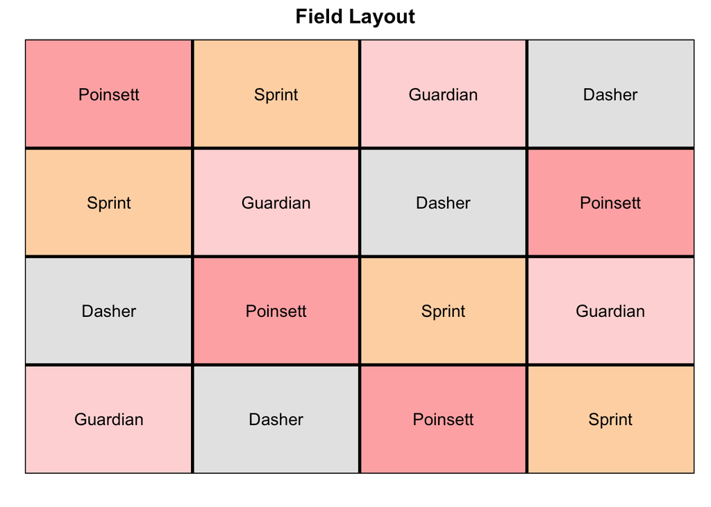

```r
desplot(data = dat, flip = TRUE,
        form = gen ~ row + col,
        out1 = row, out1.gpar = list(col = "black", lwd = 3),
        out2 = col, out2.gpar = list(col = "black", lwd = 3),
        text = gen, cex = 1, shorten = "no",
        main = "Field Layout", show.key = F)
```

It is also a good idea to look at the arithmetic means and standard deviations for each genotype row and column

```r
dat %>%
  group_by(gen) %>%
  summarize(mean = mean(yield),
            std.dev = sd(yield))
```

| gen | mean | std.dev |
| --- | --- | --- |
| Dasher | 45.550 | 7.210409 |
| Guardian | 31.625 | 12.907976 |
| Poinsett | 21.425 | 7.707734 |
| Sprint | 25.950 | 11.351799 |

```r
dat %>%
  group_by(row) %>%
  summarize(mean = mean(yield),
            std.dev = sd(yield))
```

| row | mean | std.dev |
| --- | --- | --- |
| 1 | 25.950 | 15.376280 |
| 2 | 27.600 | 18.060823 |
| 3 | 40.725 | 7.355893 |
| 4 | 30.275 | 7.277534 |

```r
dat %>%
  group_by(col) %>%
  summarize(mean = mean(yield),
            std.dev = sd(yield))
```

| col | mean | std.dev |
| --- | --- | --- |
| 1 | 28.150 | 14.903579 |
| 2 | 24.350 | 15.613776 |
| 3 | 35.925 | 9.666221 |
| 4 | 36.125 | 12.223577 |

A simple plot of the raw data also helps to visualize the distribution of the yield for each genotype The point geometry produces a scatter plot with different shapes for the columns and colors for the rows. The ylim argument forced the y-axis to start at 0. The theme_classic argument produces a clearer plot format.

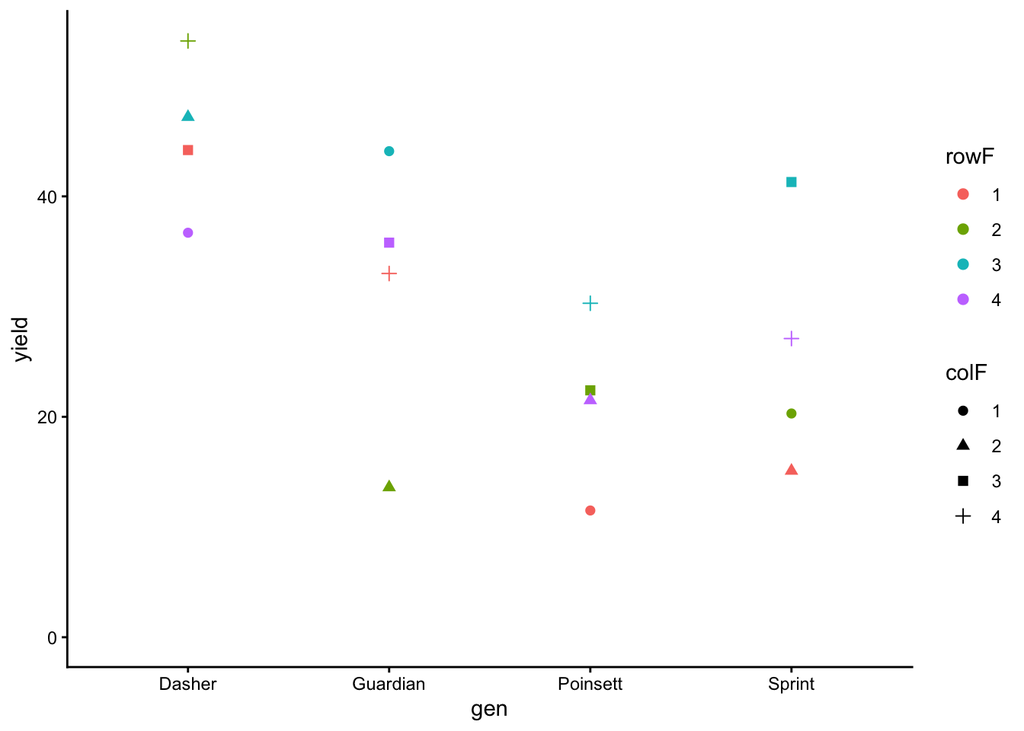

```r
ggplot(data = dat, aes(y = yield,x = gen, color = rowF, shape = colF)) +
  geom_point(size = 2) + #scatter plot with larger points
  ylim(0, NA) +
  theme_classic()
```

### 1.3.5 Fitting ANOVA Models with R

We fit a linear model with yield as the response variable and genotype as the fixed effect. The goal is to determine if there is a difference in yield between varieties and where those differences are. The row and column variables can be treated as either fixed or random effects, but we will be treating them as fixed effects for this example.

```r
mod_fe <- lm(yield ~ gen + rowF + colF, data = dat)

mod_fe %>% car::Anova(type = 2)
```

|  | Sum Sq | Df | F value | Pr(>F) |
| --- | --- | --- | --- | --- |
| gen | 1316.8025 | 3 | 9.368259 | 0.0110955 |
| rowF | 528.3525 | 3 | 3.758911 | 0.0787157 |
| colF | 411.1625 | 3 | 2.925174 | 0.1219651 |
| Residuals | 281.1200 | 6 | NA | NA |

```r
epsilon <- residuals(mod_fe) #used to test model assumptions
```

### 1.3.6 Assumptions

We show the qqnorm and residuals vs fitted plots and the formal statistical tests.

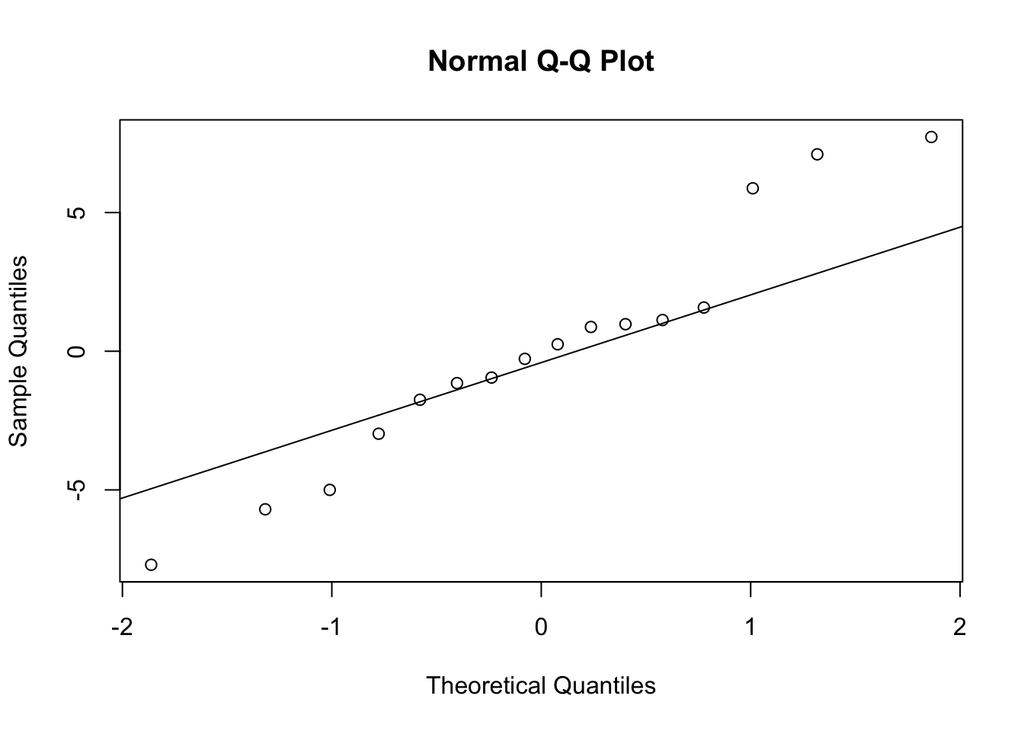

```r
qqnorm(epsilon)
qqline(epsilon)
```

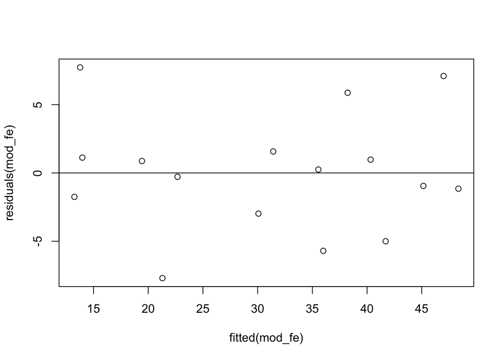

```r
plot(residuals(mod_fe) ~ fitted(mod_fe))
abline(h = 0)
```

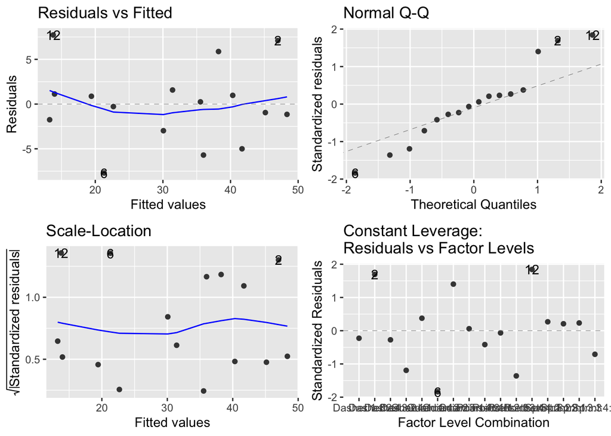

```r
autoplot(mod_fe)
```

```r
shapiro.test(epsilon)
```

```
##
##  Shapiro-Wilk normality test
##
## data:  epsilon
## W = 0.95458, p-value = 0.5655
```

```r
car::leveneTest(yield ~ gen, dat, center = mean)
```

|  | Df | F value | Pr(>F) |
| --- | --- | --- | --- |
| group | 3 | 0.5040223 | 0.6866868 |
|  | 12 | NA | NA |

Results indicate the satisfaction of linear model assumptions, so we can move onto multiple comparisons tests.

### 1.3.7 Mean Comparisons

Following a significant F-test, we can compare the genotype means.

```r
mean_comparisons_tukey_fe <- mod_fe %>%
  emmeans(specs = ~ gen) %>%
  cld(Letters = letters) #the default p-value adjustment is Tukey-HSD
mean_comparisons_tukey_fe
```

|  | gen | emmean | SE | df | lower.CL | upper.CL | .group |
| --- | --- | --- | --- | --- | --- | --- | --- |
| 3 | Poinsett | 21.425 | 3.422475 | 6 | 13.05051 | 29.79949 | a |
| 4 | Sprint | 25.950 | 3.422475 | 6 | 17.57551 | 34.32449 | a |
| 2 | Guardian | 31.625 | 3.422475 | 6 | 23.25051 | 39.99949 | ab |
| 1 | Dasher | 45.550 | 3.422475 | 6 | 37.17551 | 53.92449 | b |

### 1.3.8 Data Visualization

Create a plot that displays both the raw data and results from the multiple comparisons tests of the adjusted means from the linear model.

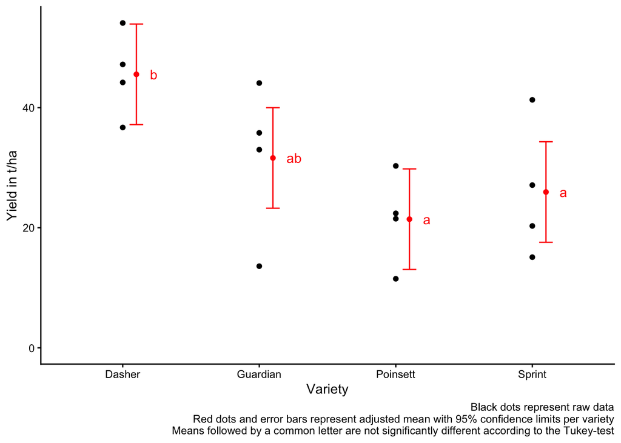

```r
CRD_Plot_tukey_fe <- ggplot() +
  # black dots representing the raw data
  geom_point(data = dat, aes(y = yield, x = gen)) +
  # red dots representing the adjusted means
  geom_point(data = mean_comparisons_tukey_fe, aes(y = emmean, x = gen), color = "red", position = position_nudge(x = 0.1)) +
  # red error bars representing the confidence limits of the adjusted means
  geom_errorbar(data = mean_comparisons_tukey_fe, aes(ymin = lower.CL, ymax = upper.CL, x = gen), color = "red", width = 0.1, position = position_nudge(x = 0.1)) +
  # red letters
  geom_text(data = mean_comparisons_tukey_fe, aes(y = emmean, x = gen, label = str_trim(.group)), color = "red", position = position_nudge(x = 0.2), hjust = 0) +
  ylim(0, NA) + # force y-axis to start at 0
  ylab("Yield in t/ha") + # label y-axis
  xlab("Variety") +      # label x-axis
  labs(caption = "Black dots represent raw data
       Red dots and error bars represent adjusted mean with 95% confidence limits per variety
       Means followed by a common letter are not significantly different according to the Tukey-test") +
  theme_classic() # clearer plot format
CRD_Plot_tukey_fe
```

## 1.4 Practice Example

We are going to reuse the example from the latin square design example but incorporate both locations to represent the combined randomized complete block design and latin square design. Make sure to address the format of variables used in the experimental design. Treat the block (location), row, and column factors as fixed effects.

```r
dat <- read_csv(here("data", "Latin_Square_Design.csv"))
str(dat)
```

```
## spc_tbl_ [32 × 5] (S3: spec_tbl_df/tbl_df/tbl/data.frame)
##  $ loc  : chr [1:32] "Clemson" "Clemson" "Clemson" "Clemson" ...
##  $ gen  : chr [1:32] "Dasher" "Dasher" "Dasher" "Dasher" ...
##  $ row  : num [1:32] 1 2 3 4 1 2 3 4 1 2 ...
##  $ col  : num [1:32] 3 4 2 1 4 2 1 3 1 3 ...
##  $ yield: num [1:32] 44.2 54.1 47.2 36.7 33 13.6 44.1 35.8 11.5 22.4 ...
##  - attr(*, "spec")=
##   .. cols(
##   ..   loc = col_character(),
##   ..   gen = col_character(),
##   ..   row = col_double(),
##   ..   col = col_double(),
##   ..   yield = col_double()
##   .. )
##  - attr(*, "problems")=<externalptr>
```

Example 1 Following the guidelines above test the following hypothesis:

1. The variation in yield is equal among the four different genotypes

Think about which type of model you need to use to test these hypotheses. Report the results from your assessments of the linear model assumptions. Use the multiple comparisons results in a final figure to demonstrate how the results support or refute the above hypotheses.